# Solutions de l’examen STAT2 – session de janvier 2018

Jacques van Helden

5 avril 2018

# 1 Partie 1 Analyse de donnéees

## 1. Charger le fichier bosson.csv placé dans amétice, onglet EXAMEN, on le nommera BOSSON (utiliser plutôt la fonction read.csv2())

Nous commençons par définir chacun.e un dossier de base (base.dir), celui où nous avons téléchargé le fichier de données.

```r
base.dir <- "/home/ilyess/Bureau/BIOSTAT/"  ## Ilyess
base.dir <- "~/stat1/practicals/consolidation_stat_2018-03/exam_stat2_2018-01"  ## Jacques
```

Nous nous positionnons dans ce dossier, ce qui évitera de manipuler de longs chemins.

```r
setwd(base.dir) # set the working directory
tableau <- read.csv2("bosson.csv", header = TRUE , sep =";", dec =".")
```

## 2. Nommer les colonnes du jeu de donn ées Pays, Genre, Anévrisme, IMC, Risque.**

On change le nom des colonnes du jeu de données avec la fonction `colnames()`

```r
colnames(tableau) <- c("Pays","Genre", "Anévrisme","IMC", "Risque")
```

## 3. Afficher les 6 premières lignes de la base. Afficher le nom des colonnes de BOSSON.

head(tableau, n = 6)

```r
head(tableau, n = 6)
```

```
##      Pays Genre Anévrisme    IMC Risque
## 1 Vietnam     M        21 21.094      0
## 2 Vietnam     M        27 19.031      0
## 3 Vietnam     M        28 20.313      0
## 4 Vietnam     F        33 17.778      0
## 5  France     F        34 21.604      0
## 6 Vietnam     F        35 21.096      0
```

## 4. Quel est le type des différentes variables ?

Réponse naïve (et fausse).

```r
typeof(tableau[,1]) #Pays : factor
```

```
## [1] "integer"
```

```r
typeof(tableau[,2]) #Genre : factor
```

```
## [1] "integer"
```

```r
typeof(tableau[,3]) #Anevrisme : integer
```

```
## [1] "integer"
```

```r
typeof(tableau[,4]) #IMC : numeric
```

```
## [1] "double"
```

```r
typeof(tableau[,5]) #Risque : integer
```

```
## [1] "integer"
```

Surprenant: `typeof()` indique “integer” pour Pays et Genre. Explication: ces colonnes sont stockées sous la forme de facteurs, c’est-à-dire des vecteurs avec un dictionnaire de valeurs associées à des indices entiers. Ce qui est entier n’est pas le type des valeurs, mais le type des indices du facteur.

Nous pouvons obtenir le type des valeurs en convertissant préalablement chaque colonne en vecteur. Réponse avancée: on observe la structure de données de chaque colonne.

```r
for (i in 1:ncol(tableau)) {
   print(
     paste(collapse="\t",
           i,
           colnames(tableau[,i]),
           class(tableau[,i]),
           typeof(tableau[,i]),
           typeof(as.vector(tableau[,i]))
           )
     )
}
```

```
## [1] "1  factor integer character"
## [1] "2  factor integer character"
## [1] "3  integer integer integer"
## [1] "4  numeric double double"
## [1] "5  integer integer integer"
```

## 5. Séparer dans deux data.frames les données concernant les patients vietnamiens et fran ̧cais.

Data.frame contenant les données relatives aux patients français:

```r
tableauFR <-  subset(tableau, Pays== "France")
dim(tableauFR)
```

```
## [1] 99  5
```

```r
head(tableauFR)
```

```
##      Pays Genre Anévrisme    IMC Risque
## 5  France     F        34 21.604      0
## 8  France     M        35 22.583      0
## 10 France     F        39 24.035      0
## 11 France     F        39 24.035      0
## 14 France     M        43 26.675      0
## 15 France     M        44 21.857      0
```

```r
tail(tableauFR)
```

```
##       Pays Genre Anévrisme    IMC Risque
## 204 France     M        36 29.758      3
## 205 France     M        30 29.411      4
## 206 France     M        50 32.000      4
## 207 France     M        67 27.084      4
## 208 France     M        75 27.441      4
## 209 France     M        35 28.056      5
```

Data.frame contenant les données relatives aux patients vietnamiens:

```r
tableauVT= subset(tableau, Pays== "Vietnam")
dim(tableauVT)
```

```
## [1] 110   5
```

```r
head(tableauVT)
```

```
##      Pays Genre Anévrisme    IMC Risque
## 1 Vietnam     M        21 21.094      0
## 2 Vietnam     M        27 19.031      0
## 3 Vietnam     M        28 20.313      0
## 4 Vietnam     F        33 17.778      0
## 6 Vietnam     F        35 21.096      0
## 7 Vietnam     F        35 17.778      0
```

```r
tail(tableauVT)
```

```
##        Pays Genre Anévrisme    IMC Risque
## 183 Vietnam     M        29 14.568      3
## 184 Vietnam     M        30 22.206      3
## 185 Vietnam     M        32 20.196      3
## 186 Vietnam     M        32 22.206      3
## 188 Vietnam     M        41 20.761      3
## 196 Vietnam     M        53 24.802      3
```

Utilisation avancée: sélectionner les françaises ayant un indice de masse corporelle > 28.

```r
subset(tableau, Pays== "France" & Genre == "F" & IMC > 28)
```

```
##       Pays Genre Anévrisme    IMC Risque
## 80  France     F        43 29.395      1
## 113 France     F        65 28.345      1
```

## 6. Quel est le nombre de facteurs de risque moyen des hommes, des femmes ?

```r
risqueHommes <- subset(tableau, Genre=="M"); risqueHommes
```

```
##        Pays Genre Anévrisme    IMC Risque
## 1   Vietnam     M        21 21.094      0
## 2   Vietnam     M        27 19.031      0
## 3   Vietnam     M        28 20.313      0
## 8    France     M        35 22.583      0
## 14   France     M        43 26.675      0
## 15   France     M        44 21.857      0
## 16  Vietnam     M        44 23.438      0
## 17  Vietnam     M        44 23.875      0
## 18  Vietnam     M        46 18.365      0
## 19  Vietnam     M        47 22.232      0
## 20  Vietnam     M        47 16.947      0
## 23  Vietnam     M        48 20.576      0
## 25   France     M        51 25.763      0
## 27   France     M        52 24.152      0
```

[output cut: 144 more lines]

```r
mean(risqueHommes$Risque)  # 1.56
```

```
## [1] 1.563291
```

```r
risqueFemmes <- subset(tableau, Genre=="F"); risqueFemmes
```

```
##        Pays Genre Anévrisme    IMC Risque
## 4   Vietnam     F        33 17.778      0
## 5    France     F        34 21.604      0
## 6   Vietnam     F        35 21.096      0
## 7   Vietnam     F        35 17.778      0
## 9   Vietnam     F        37 21.914      0
## 10   France     F        39 24.035      0
## 11   France     F        39 24.035      0
## 12  Vietnam     F        40 13.333      0
## 13  Vietnam     F        43 19.477      0
## 21  Vietnam     F        47 21.094      0
## 22   France     F        48 25.911      0
## 24  Vietnam     F        50 16.649      0
## 26  Vietnam     F        52 17.710      0
## 36  Vietnam     F        65 15.111      0
```

[output cut: 37 more lines]

```r
mean(risqueFemmes$Risque) #0.84
```

```
## [1] 0.8431373
```

Solution plus élégante: essayez la fonction by() (utilisez l’aide).

```r
# help(by)
by(data = tableau$Risque,
   INDICES = tableau$Genre,
   FUN = mean)
```

```
## tableau$Genre: F
## [1] 0.8431373
## --------------------------------------------------------
## tableau$Genre: M
## [1] 1.563291
```

```r
hommes<- subset(tableau, Genre =="M")
moyH<- mean(hommes$Risque)
moyH
```

```
## [1] 1.563291
```

```r
femmes<- subset(tableau, Genre =="F")
moyF<- mean(femmes$Risque)
moyF
```

```
## [1] 0.8431373
```

## 7. Calculer les effectifs et les proportions d’hommes et femmes.

```r
tableauHommes <- subset(tableau, Genre=="M"); tableauHommes
```

```
##        Pays Genre Anévrisme    IMC Risque
## 1   Vietnam     M        21 21.094      0
## 2   Vietnam     M        27 19.031      0
## 3   Vietnam     M        28 20.313      0
## 8    France     M        35 22.583      0
## 14   France     M        43 26.675      0
## 15   France     M        44 21.857      0
## 16  Vietnam     M        44 23.438      0
## 17  Vietnam     M        44 23.875      0
## 18  Vietnam     M        46 18.365      0
## 19  Vietnam     M        47 22.232      0
## 20  Vietnam     M        47 16.947      0
## 23  Vietnam     M        48 20.576      0
## 25   France     M        51 25.763      0
## 27   France     M        52 24.152      0
```

[output cut: 144 more lines]

```r
tableauFemmes <- subset(tableau, Genre=="F"); tableauFemmes
```

```
##        Pays Genre Anévrisme    IMC Risque
## 4   Vietnam     F        33 17.778      0
## 5    France     F        34 21.604      0
## 6   Vietnam     F        35 21.096      0
## 7   Vietnam     F        35 17.778      0
## 9   Vietnam     F        37 21.914      0
## 10   France     F        39 24.035      0
## 11   France     F        39 24.035      0
## 12  Vietnam     F        40 13.333      0
## 13  Vietnam     F        43 19.477      0
## 21  Vietnam     F        47 21.094      0
## 22   France     F        48 25.911      0
## 24  Vietnam     F        50 16.649      0
## 26  Vietnam     F        52 17.710      0
## 36  Vietnam     F        65 15.111      0
```

[output cut: 37 more lines]

```r
effectifHommes <- nrow(tableauHommes);
message("Effectif hommes = ", effectifHommes)
```

```
## Effectif hommes = 158
```

```r
effectifFemmes <- nrow(tableauFemmes);
message("Effectif femme = ", effectifFemmes)
```

```
## Effectif femme = 51
```

```r
proportionHommes <- effectifHommes / nrow(tableau)
message("Proportion hommes = ", round(digits=2, proportionHommes))
```

```
## Proportion hommes = 0.76
```

```r
proportionFemmes <-  effectifFemmes/nrow(tableau)
message("Proportion femmes = ", round(digits=2, proportionFemmes))
```

```
## Proportion femmes = 0.24
```

## 8. Quelle est la proportion de vietnamiens dans le data frame ?

```r
effectifVietnamiens = nrow(subset(tableau, Pays=="Vietnam"))
message("Effectif Vietnamiens = ", effectifVietnamiens)
```

```
## Effectif Vietnamiens = 110
```

```r
proportionsVietnamiens <-effectifVietnamiens/nrow(tableau)
message ("Proportion Vietnamiens = ", round(digits=2, proportionsVietnamiens))
```

```
## Proportion Vietnamiens = 0.53
```

## 9. Tracer la répartition du genre selon le pays.

```r
## Calcul d'une table de confusion genre versus pays
table(tableau$Pays, tableau$Genre)
```

```
##
##            F  M
##   France  15 84
##   Vietnam 36 74
```

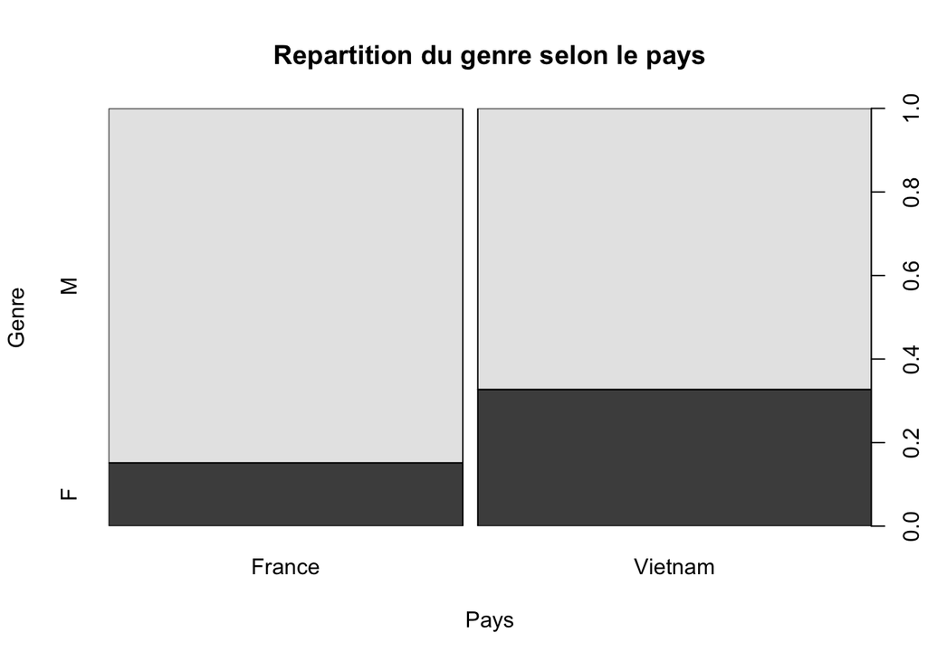

```r
## Quand on donne à la fonction plot 2 vecteurs de chaînes de caractères, elle calcule automatiquement une table de confusion (avec les proportions) et la dessine
plot(tableau$Pays, tableau$Genre,
     main="Repartition du genre selon le pays",
     ylab = "Genre", xlab ="Pays")
```

```r
help("plot.table")
```

## 10. Tracer une représentation du nombre de facteurs de risque selon le pays.

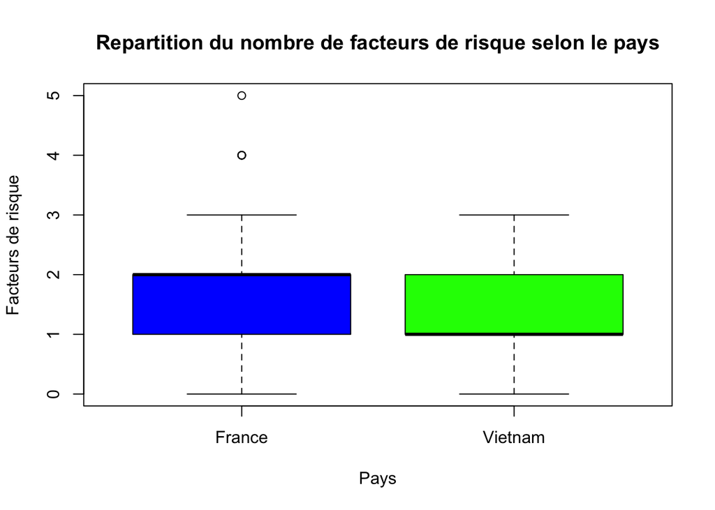

```r
## Box plot
plot(tableau$Pays, tableau$Risque, main="Repartition du nombre de facteurs de risque selon le pays", ylab = "Facteurs de risque", xlab ="Pays", type ="l", col=c("blue", "green"))
```

Alternative: dessiner 2 histogrammes dans des panneaux séparés.

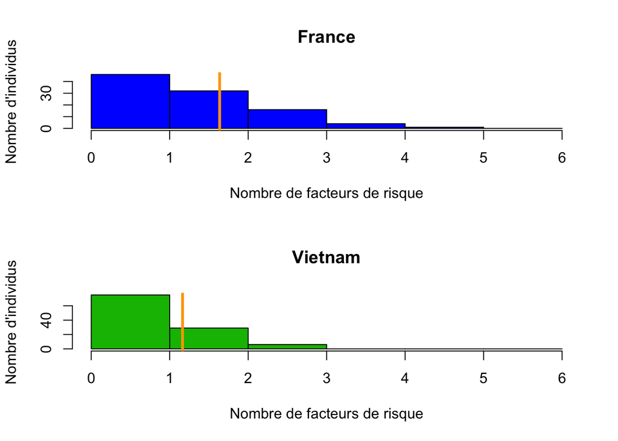

```r
par(mfrow=c(2,1))## Subdiviser l'espace graphique en 2 panneaux horizontaux

risqueFrance <- unlist(subset(tableau, Pays=="France", select = "Risque"))

h.France <- hist(x = risqueFrance, breaks=0:(max(tableau$Risque)+1), main = "France", xlab="Nombre de facteurs de risque", ylab = "Nombre d'individus", col="blue")

abline(v=mean(risqueFrance), col="orange", lwd=3)

risqueVietnam <- unlist(subset(tableau, Pays=="Vietnam", select = "Risque"))

h.Vietnam <- hist(x = risqueVietnam, breaks=0:(max(tableau$Risque)+1), main = "Vietnam", xlab="Nombre de facteurs de risque", ylab = "Nombre d'individus", col="#00BB00")

abline(v=mean(risqueVietnam), col="orange", lwd=3)
```

```r
par(mfrow=c(1,1))

# sum(tableau$Pays == "France")
# sum(h.France$counts)
```

## 11. Tracer un boxplot de la colonne anévrisme en fonction du genre.

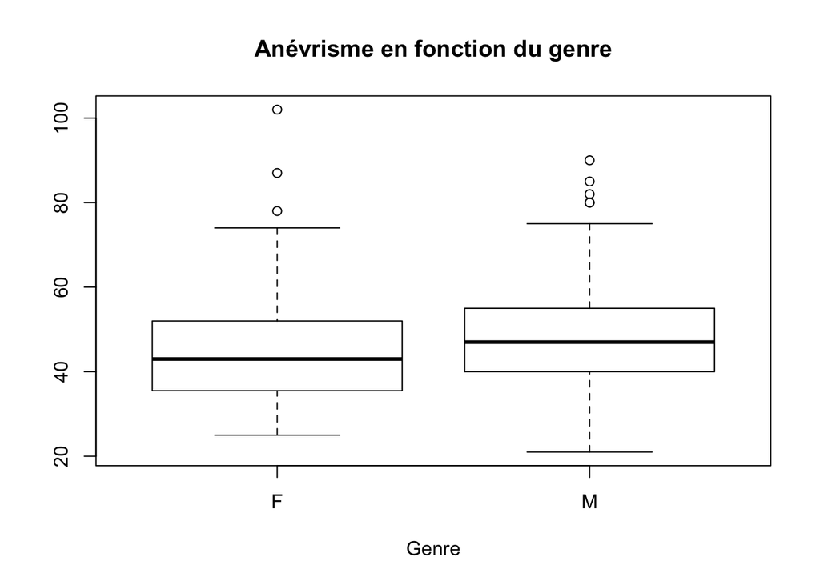

```r
## La solution d'Ilyes (trouvée sur Internet): Utiliser la fonciton split() pour séparer les valeurs d'anévrisme selon les genres
anevrisme.par.genre <- split(tableau$Anévrisme, tableau$Genre)

boxplot(split(tableau$Anévrisme, tableau$Genre), main="Anévrisme en fonction du genre", xlab="Genre")
```

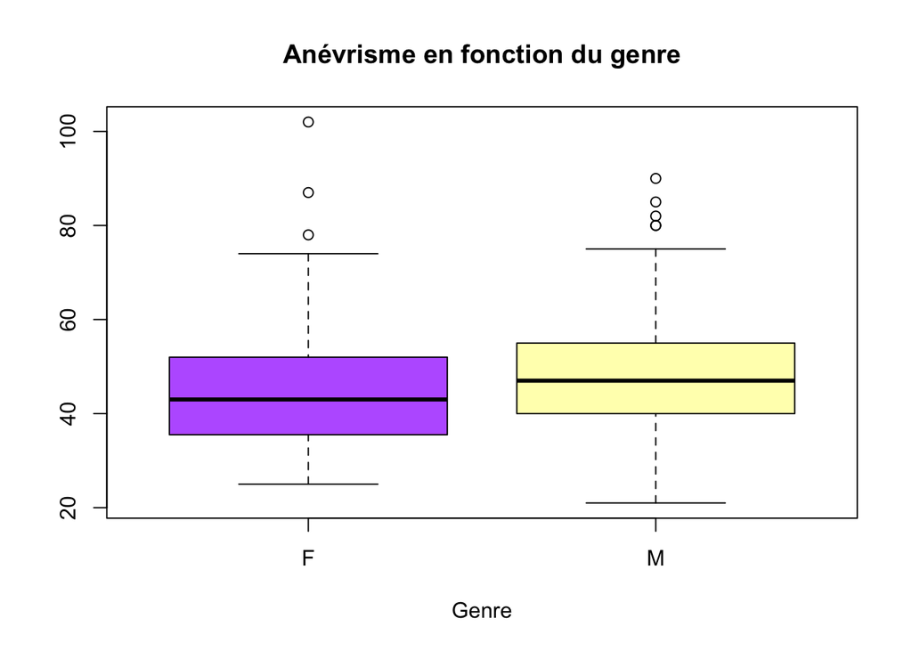

```r
## Solution plus directe: utiliser une formule dans la fonction boxplot
boxplot(formula= Anévrisme ~ Genre, data=tableau,
        main="Anévrisme en fonction du genre", xlab="Genre", col= c("#BB66FF", "#FFFFBB"))
```

Plus élaboré: boxplot en séparant par genre + pays

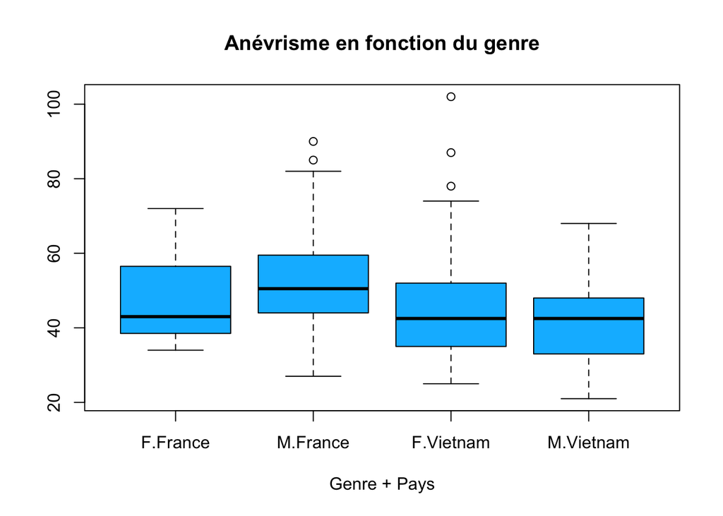

```r
boxplot(formula= Anévrisme ~ Genre + Pays, data=tableau,
        main="Anévrisme en fonction du genre", xlab="Genre + Pays", col="#00BBFF")
```

## 12. Est-ce que les moyennes de la taille des anévrismes des hommes et des femmes diffèrent de façon significative ? On effectuera un test de Student, dont on extraira en particulier la p value.

Attention, ne pas oublier de préciser les paramètres du test de Student.

```r
## Séparer les valeurs d'anévrismes par genre
anevrisme.par.genre <- split(tableau$Anévrisme, tableau$Genre)

t.result <- t.test(x= anevrisme.par.genre$F , y = anevrisme.par.genre$M,
       alternative = "two.sided", var.equal = TRUE)

print(t.result)
```

```
##
##  Two Sample t-test
##
## data:  anevrisme.par.genre$F and anevrisme.par.genre$M
## t = -0.23395, df = 207, p-value = 0.8153
## alternative hypothesis: true difference in means is not equal to 0
## 95 percent confidence interval:
##  -4.899545  3.860081
## sample estimates:
## mean of x mean of y
##  47.17647  47.69620
```

Résultat:

- la p-valeur vaut 0.8153, ce qui est énorme, on peut donc accepter l’hypothèse nulle
- Remarque: ici on a appliqué un test de Student pour suivre les instructions, mais on aurait pu préalablement évaluer s’il était plus approrpié de faire un test de Welch, en réalisant un test de comparaison de variances (pas vu au cours).

Approfondissement

```r
## Explorer les propriétés de la liste retournée par split()
class(anevrisme.par.genre) ## L'objet retourné est une liste
```

```
## [1] "list"
```

```r
length(anevrisme.par.genre) ## La liste contient 2 éléments
```

```
## [1] 2
```

```r
names(anevrisme.par.genre) ## Ces éléments sont respectivement nommés "F" (féminin) et "M" (masculin)
```

```
## [1] "F" "M"
```

```r
lapply(anevrisme.par.genre, mean) ## Calculer la moyenne par genre
```

```
## $F
## [1] 47.17647
##
## $M
## [1] 47.6962
```

```r
lapply(anevrisme.par.genre, median) ## Médiane par genre
```

```
## $F
## [1] 43
##
## $M
## [1] 47
```

```r
lapply(anevrisme.par.genre, sd) ## Estimation de l'écart-type de population par genre
```

```
## $F
## [1] 16.37157
##
## $M
## [1] 12.86565
```

```r
lapply(anevrisme.par.genre, length) ## Effectif par genre
```

```
## $F
## [1] 51
##
## $M
## [1] 158
```

```r
## Récupérer des vecteur avec les paramètres du test de Student
moyennes <- unlist(lapply(anevrisme.par.genre, mean))  ## Moyenne par genre
effectifs<- unlist(lapply(anevrisme.par.genre, length))  ## Effectif par genre
sum(1/effectifs)
```

```
## [1] 0.02593696
```

Effectuer un test (de Fisher) d’égalité de variance

$H_0: \sigma_F = \sigma_H$

```r
var.test(x = anevrisme.par.genre$F, y = anevrisme.par.genre$M, alternative = "two.sided")
```

```
##
##  F test to compare two variances
##
## data:  anevrisme.par.genre$F and anevrisme.par.genre$M
## F = 1.6193, num df = 50, denom df = 157, p-value = 0.0268
## alternative hypothesis: true ratio of variances is not equal to 1
## 95 percent confidence interval:
##  1.056205 2.619598
## sample estimates:
## ratio of variances
##           1.619262
```

## 13. De même on regardera s’il y a une différence entre les moyennes de la taille des anévrismes des franc ̧ais (hommes et femmes) et des vietnamiens(hommes et femmes).

## 14. Tracer deux histogrammes de fréquence de la taille des anévrismes des femmes en vert, et de celle des hommes en bleu.

## 15. Donner une représentation graphique permettant de comparer la variabilité de la variable ≪ taille des anévrismes ≫ chez les hommes et les femmes. Peut-on au vu de ce graphique considérer les variances égales ?

## 16. Donner une représentation de la variable risque selon le pays d’origine.

## 17. Y-a -t-il une différence significative entre l’IMC des individus franc ̧ais et vietnamiens ? On répondra par une méthode laissée au choix.

# Partie 2 Simulations

## 1. Générer n=50 vecteurs de taille 100 suivant une loi continue uniforme sur l’intervalle [0,1]. Ces valeurs seront placées par construction sous forme de matrice M à 50 lignes.

```r
n <- 50 ## Nombre de vecteurs
L <- 100 ## Longueur des vecteurs

M <- matrix(nrow = n, ncol = L, runif(n = n*L))
```

Avancé: on fait la même chose avec $n = 10000$ plutôt que $n=50$, afin de disposer d’un nombre suffisant de répliques pour voir sortir les tendances.

```r
n <- 10000 ## Nombre de vecteurs
L <- 100 ## Longueur des vecteurs

M <- matrix(nrow = n, ncol = L, runif(n = n*L))
```

## 2. Effectuer à l’aide d’une boucle 50 tests de Student de comparaison de la moyenne observée pour chaque vecteur (ligne de M), à la moyenne théorique mu=0.5. On pourra utiliser la fonction t.test avec l’argument mu=0.5.

```r
t.test.results <- list()

for (i in 1:n) {
  x <- M[i, ]
  t.test.results[[i]] <- t.test(x = x, mu = 0.5)
}
```

Avancé: on applique le test de student à chaque ligne du tableau avec la fonction `apply()`. Ceci évite les boucles, qui sont coûteuses en temps avec le langage R.

```r
t.test.result2 <- apply(M, 1, t.test, mu=0.5)
class(t.test.result2)
```

```
## [1] "list"
```

```r
length(t.test.result2)
```

```
## [1] 10000
```

## 3. On conservera uniquement la p-value de ces tests, dans un vecteur numérique ValeurP.

```r
pvalues <- vector()

for (i in 1:n) {
  x <- M[i, ]
  t.test.result <- t.test(x = x, mu = 0.5)
  pvalues <- append(pvalues, t.test.result$p.value)
}
```

Avancé: dessiner l’histogramme des p-valeurs.

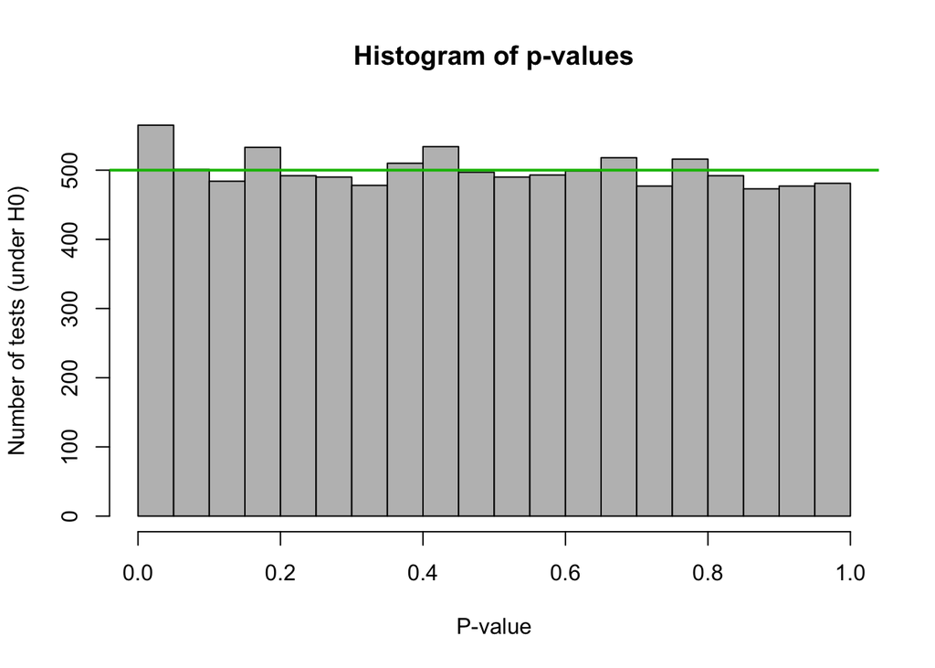

```r
pval.breaks <- seq(from=0, to=1, by=0.05) ## intervalles pour l'histogramme
hist(pvalues, breaks=pval.breaks,
     col="gray", main="Histogram of p-values", xlab="P-value", ylab="Number of tests (under H0)")

## Nombre attendu de résultats par groupe de p-valeurs
abline(h=n/(length(pval.breaks)-1), col="#00BB00", lwd=2)
```

## 4. Compter le nombre de tests pour lesquels on peut conclure que la moyenne observée est significativement différente de mu=0.5.

```r
alpha <- 0.05
sum(pvalues  < alpha)
```

```
## [1] 565
```

```r
table(pvalues < alpha)
```

```
##
## FALSE  TRUE
##  9435   565
```

## 5. Refaire le même travail (à l’aide d’une fonction si possible), mais en prenant pour chaque vecteur seulement la moyenne de ses 10 premières valeurs. On placera les résultats obtenus dans la variable MO10. De même pour MO50 (moyenne des 50 premières valeurs de chaque vecteur).

```r
t.test.subset <- function() {

}
```

## 6. Tracer sur le mˆeme graphique les histogramme de fréquences de M, M010, M050. Superposer la courbe de la loi normale de moyenne 0.5 et variance 1/12.